# Albert Raya-Munté

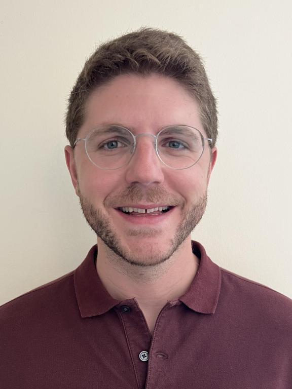

**Bio:** Albert Raya-Munté is an Economist at Amazon’s PXT Central Science, where he leads research on labor market dynamics across U.S. geographies. His work informs labor planning for operations associates, in the short term but also in the long term. By integrating structural and reduced-form econometric methodologies with advanced machine learning techniques, he addresses critical business challenges on a large scale. Albert holds a Ph.D. and M.A. in Economics from the University of Minnesota, and a B.S. in Economics and Bachelor of Laws from Universitat Pompeu Fabra. Albert has consulted for the Inter-American Development Bank, analyzing the economic impacts of COVID-19, and contributed to research at the Federal Reserve Bank of Minneapolis on international capital flows. In addition to his research, Albert is an experienced educator, having taught economics courses to undergraduate students. His research interests include heterogeneous household behavior, labor economics, and macroeconomic modeling.

**Presentation Title:** Time Series Forecasting Using Deep Learning

**Abstract:** The presentation discusses the growing application of deep learning (DL) in time series forecasting. It highlights the advantages and disadvantages of traditional statistical models versus machine learning approaches. The presentation explores the use of a popular open-source Recurrent Neural Network algorithm, showcasing its superior accuracy in predicting U.S. food prices over optimized ARIMA models. However, it emphasizes the need for large datasets for DL models to be effective. The concluding remarks suggest that while DL holds promise, successful implementation requires careful model selection, further methodological advancements, and balancing accuracy with interpretability, especially in policy-making environments.

Contact the author for the presentation slides